# SOTU Analysis

## USA State of the Union Analysis

### Data Processing

First, we write Python code that parses each SOU address, finding end-of-sentence markers.

```python
import json  # in import cell
import numpy as np
import matplotlib.pyplot as plt
import nltk
from nltk import tokenize
#nltk.download('punkt')
from nltk.tokenize import sent_tokenize, word_tokenize
import statistics as stat

with open('speeches.json', 'r') as f:
    speeches = json.loads(f.read())

for i in range(len(speeches)):
    speeches[i]['sentence'] = sent_tokenize(speeches[i]['text'])
    for sentence_i in range(len(speeches[i]['sentence'])):
        speeches[i]['sentence'][sentence_i] = speeches[i]['sentence'][sentence_i].rstrip("\n\r")
    #Create template of dimension (#sentences)
    speeches[i]['word'] = np.empty([len(speeches[i]['sentence'])])
    for j in range(len(speeches[i]['sentence'])):
        #Find number of words
        speeches[i]['word'][j] = len(word_tokenize(speeches[i]['sentence'][j]))
```

Here, we use the function sent_tokenize and word_tokenize from the nltk.tokenize package to split the SOU addresses into sentences. Note that the examples of "Mr." are specifically handled in this package, i.e. the sentence will not split there.

### Regression

How has the length of the address changed over the 200 years? For each year, we compute the number of sentences in the address, and the mean sentence length in words for that year.

```python
"""
Here, we form the data matrix.
which_year_list: List of years e.g. 1800,..., 2010
num_sentences_list: number of sentences for a given year,
                    list is for all 226 years
average_length_list: average sentence length for a given year
"""

#Form the data matrix
num_year = len(speeches)
which_year_list = np.empty(num_year)
num_sentences_list = np.empty(num_year)
average_length_list = np.empty(num_year)

for yr in range(num_year):
    num_sentences_list[yr] = len(speeches[yr]['sentence'])
    average_length_list[yr] = stat.mean(speeches[yr]['word'])
    which_year_list[yr] = speeches[yr]['year']
```

```
[-1.21410508e+03  7.85511327e-01]
```

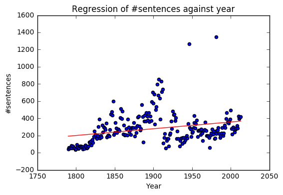

```python
"""
Regress #Sentences against year
"""
X = np.vstack((np.repeat(1,226), which_year_list)).T
inverse = np.linalg.inv(np.matmul(X.T,X))
XtY = np.matmul(X.T,num_sentences_list)
beta = np.matmul(inverse, XtY)
Y_hat = np.matmul(X, beta)
print(beta)

plt.scatter(which_year_list, num_sentences_list)
plt.plot(X[:,1], Y_hat,'r')
plt.ylabel("#sentences")
plt.xlabel("Year")
plt.title("Regression of #sentences against year")
plt.show()
```

Recall that $\hat{Y} = X\hat{\beta}$, where $\hat{\beta}$ is given by $(X^T X)^{-1} X^T Y$. Hence $\hat{Y} = X (X^T X)^{-1} X^T Y$.

Note that from the regression, the coefficient for year is 0.785. This implies that the expected increase in number of sentences for every passing year is 0.785.

However, from the points, notice that while the trend is increasing overall, there is a structural change in the year ~1910, when the number of sentences decrease before increasing again, although at a slower pace than before 1910. The structural change will be explained in Part (c).

```
[ 2.66839367e+02 -1.23061164e-01]
```

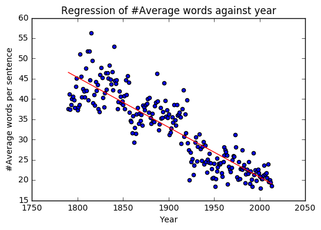

```python
"""
Regress average #words per sentence against year
"""
XtY2 = np.matmul(X.T,average_length_list)
beta2 = np.matmul(inverse, XtY2)
Y_hat2 = np.matmul(X, beta2)
print(beta2)

plt.scatter(which_year_list, average_length_list)
plt.plot(X[:,1], Y_hat2,'r')
plt.ylabel("#Average words per sentence")
plt.xlabel("Year")
plt.title("Regression of #Average words against year")
plt.show()
```

Next, we analyze the regression of average length of sentence against year. Here, the coefficient for year is -0.123, implying that for every passing year, the average number of words in a sentence decreases by 0.123, hence each sentence is getting shorter and shorter.

Overall in general, we observe that as the years pass, the number of sentences tends to increase, but the average length of the sentences decreases. This could be due to changes in linguistic preferences - people in the past tend to contain more of their words in a sentence, hence as the sentence length decreases, the number of sentence must increase to convey the same (or more) amount of content. There is a structural change in ~1910s which will be further explored in the next part.

### Splitting of Eras

Now, we compute two regressions of the total number of words in a SOU versus year–one for the years 1790 to 1912, another for the years 1913 to the present.

```python
totalwords_list = np.empty(num_year)
for yr in range(num_year):
    totalwords_list[yr] = sum(speeches[yr]['word'])

#Split data into 2 eras
np.where(which_year_list == 1913)
A_year = which_year_list[:123]
B_year = which_year_list[123:]
A_totalwords_list = totalwords_list[:123]
B_totalwords_list = totalwords_list[123:]
```

```python
#First group of years
Xa = np.vstack((np.repeat(1,123), A_year)).T
inverse_3a = np.linalg.inv(np.matmul(Xa.T,Xa))
XtY_3a = np.matmul(Xa.T,A_totalwords_list)
beta3a = np.matmul(inverse_3a, XtY_3a)
Y_hat3a = np.matmul(Xa, beta3a)
print("Beta for first set of years: ", beta3a)

#Second group of years
Xb = np.vstack((np.repeat(1,103), B_year)).T
inverse_3b = np.linalg.inv(np.matmul(Xb.T,Xb))
XtY_3b = np.matmul(Xb.T,B_totalwords_list)
beta3b = np.matmul(inverse_3b, XtY_3b)
Y_hat3b = np.matmul(Xb, beta3b)
print("Beta for 2nd set of years: ", beta3b)
```

```
Beta for first set of years:  [-2.70689040e+05  1.52065677e+02]
Beta for 2nd set of years:  [-1.04629782e+04  8.65615405e+00]
```

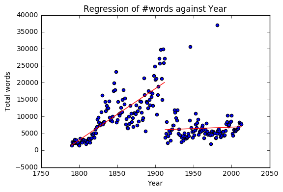

```python
plt.scatter(which_year_list,totalwords_list)
plt.plot(Xa[:,1], Y_hat3a,'r')
plt.plot(Xb[:,1], Y_hat3b,'r')
plt.ylabel("Total words")
plt.xlabel("Year")
plt.title("Regression of #words against Year")
plt.show()
```

In this case, note that the total number of words is the best indication of the total length of the speech compared to either the number of sentences and average number of words in sentence. Here, we are measuring the overall length of speeches have changed.

The coefficients for the first set of years is 152, and the 2nd set of years is 8.6. This implies that before 1913, the expected increase in speech length for every passing year is 152, and after 1913, this number drops to 8.6. Hence, the speech grows at a much faster pace before 1913 compared to after 1913. This is because before 1913, the President primarily only submitted a written report to Congress. After 1913, Woodrow Wilson, the 28th U.S. President, began the regular practice of delivering the address to Congress in person.

Hence, since the speech was only done in writing before 1913, the increase in length is more drastic, since the President picks up the habit of writing the report to convey more of his objectives, and it is easier to say more in a report than in person. After 1913, when the speech is done in person, there is a drastic drop, since it is not possible to give too long a speech - this also accounts for why the increase in speech length after 1913 is only 8.6 which is close to 0 - it is not possible for the speech to grow too long given that the timing is rather fixed.

### Comparing Presidents

Which President has the longest sentences on average? Which has the shortest sentences? What is the distribution of the sentence length? We also explore what are the longest and shortest sentences ever recorded in the SOTU speech.

```python
#FIND list of presidents
president_list = []
for i in range(num_year):
    president_list.append(speeches[i]['president'])
president_list=np.unique(president_list)

#Find the average sentence length of each president
president_sentence_len = np.empty(len(president_list))
for pres in range(len(president_list)):
    #We find the total number of words,
    #and total number of sentences of each president
    num_sentences_pres = 0
    num_words_pres = 0
    for year in range(num_year):
        if speeches[year]['president']==president_list[pres]:
            num_words_pres = num_words_pres + totalwords_list[year]
            num_sentences_pres = num_sentences_pres + num_sentences_list[year]
    president_sentence_len[pres] = num_words_pres/num_sentences_pres
```

```python
print("Longest sentence President: ",
      president_list[np.argmax(president_sentence_len)])
print("Shortest sentence President: ",
      president_list[np.argmin(president_sentence_len)])

first_quad = np.quantile(president_sentence_len,0.25)
median = np.quantile(president_sentence_len,0.5)
third_quad = np.quantile(president_sentence_len,0.75)
firstquad_pres = president_list[np.where(president_sentence_len == first_quad)]
median_pres = president_list[np.where(president_sentence_len == median)]
thirdquad_pres = president_list[np.where(president_sentence_len == third_quad)]

print("First quantile President: ", firstquad_pres, "Length: ",
      first_quad)
print("Median President: ", median_pres, "Length: ", median)
print("Third quantile President: ", thirdquad_pres, "Length: ",
      third_quad)
```

```
Longest sentence President:  James Madison
Shortest sentence President:  George Bush
First quantile President:  ['Jimmy Carter'] Length:  25.705028512182476
Median President:  ['Chester A. Arthur'] Length:  34.752553024351926
Third quantile President:  ['Zachary Taylor'] Length:  39.5
```

The president that has the longest sentence is James Madison. The one with shortest sentence is George Bush.

The first quantile's length is 25.7 (Jimmy Carter); the median length is 34.75 (Chester Arthur), and the third quantile's length is 39.5 (Zachary Taylor).

```python
#Join all sentences into a list
sentences_data = []
sentences_len = []
for yr in range(num_year):
    sentences_data = np.append(sentences_data,
                               speeches[yr]['sentence'])
    sentences_len = np.append(sentences_len,
                              speeches[yr]['word'])

print("Shortest sentence ", min(sentences_len))
print("What is Shortest sentence: ",
      sentences_data[np.where(sentences_len == min(sentences_len))])

print("Longest sentence ", max(sentences_len))
#print("What is Longest sentence: ",
#      sentences_data[np.where(sentences_len == max(sentences_len))])
```

```
Shortest sentence  1.0
What is Shortest sentence:  ['WASHINGTON' 'WASHINGTON' 'WASHINGTON' 'WASHINGTON' 'WASHINGTON'
 'WASHINGTON' 'WASHINGTON' 'JEFFERSON' 'JEFFERSON' 'JEFFERSON' 'JEFFERSON'
 'JEFFERSON' 'JEFFERSON' 'JEFFERSON' 'JEFFERSON' '.' 'HARRISON' 'HARRISON'
 'HARRISON' 'HARRISON' '.' '.' '.' '.' '.' '.' '.' '.' '.' '.' '.' '.' '.'
 '.' '.' '.' '.' '.' '.' '.' '.' '.' '.' '.' '.' '.' '.' '.' '.' '.' '.'
 '.' '.' '.' '.' '.' '.']
Longest sentence  679.0
```

The shortest sentence consists of 1 word, and the longest is 679 words. The shortest sentences consists of either a person's name normally recorded at the end of the speech or a full stop, which is due to the parsing method.

The longest sentence is the following: *It shows that the ordinary revenues from all sources for the fiscal year ended June 30, 1883, amounted to \$ 398,287,581.95, whereof there was received ... the revenue for the fiscal year which will end on June 30, 1885, be estimated upon the basis of existing laws, the Secretary is of the opinion that for that year the receipts will exceed by $60,000,000 the ordinary expenditures including the amount devoted to the sinking fund.*

This is a finance-related sentence, and is most likely a expenditure record included as part of a record. Note that there are 679 words recorded since some line breaks are consisted as 1 word.